# Bi-linear Transformation for the Routh-Hurwitz Criterion & MATLAB

## The Bilinear Transformation: a Recap

$z = \frac{w+1}{w-1}, \; z, \, w \in \mathbb C \quad \quad \quad \quad\quad \begin{array}{l} \vert z \vert < 1 \, \, \Longleftrightarrow \, \, {\rm Re} (w) < 0 \\ \vert z \vert = 1 \, \, \Longleftrightarrow \, \, {\rm Re} (w) = 0 \\ \vert z \vert > 1 \, \, \Longleftrightarrow \, \, {\rm Re} (w) > 0 \end{array}$

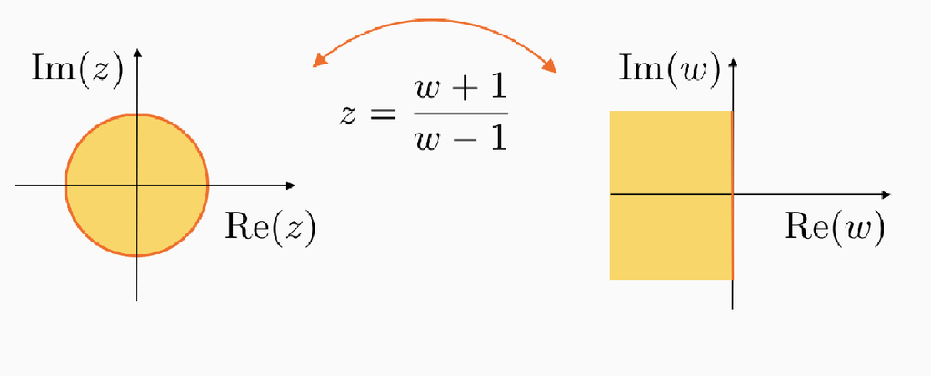

Substitute

$z = \frac{w+1}{w-1}, \; z, \, w \in \mathbb C$

into $p_A (z) = \varphi_0 z^n + \varphi_1 z^{n-1} + \cdots + \varphi_{n-1} z + \varphi_n$, thus obtaining

$\begin{array}{l} q_A (w) = \, \left(w-1 \right)^n \, \left[ \varphi_0 \frac{\left(w+1 \right)^n}{\left(w-1 \right)^n} + \varphi_1 \frac{\left(w+1 \right)^{n-1}}{\left(w-1 \right)^{n-1}} + \cdots + \varphi_{n-1} \frac{\left(w+1 \right)}{\left(w-1 \right)} + \varphi_{n} \right ] \end{array}$

and hence one gets

$q_A(w) = q_0 \, w^n + q_1\,w^{n-1}+\cdots+q_{n-1}\,w + q_n$

with suitable coefficients $q_0, \, q_1, \ldots, q_n$.

## Applying the Bilinear Transformation In MATLAB

Given

$p_A(z) \;=\; z^3+2\,z^2+z+1$

one gets

$q_A(w) \;=\;(w-1)^3 \, \left[ \displaystyle \frac{(w+1)^3}{(w-1)^3}+2\, \frac{(w+1)^2}{(w-1)^2}+\frac{w+1}{w-1}+1 \right]$

and after some algebra

$q_A(w) =5\,w^3+w^2+3\,w-1$

Let us replicate the application of the bilinear transform using the Symbolic Math Toolbox in MATLAB.

```matlab
clear
close all
clc

syms z w % let's declare a few symbolic variables
```

```matlab
p_Az = z^3+2*z^2+z+1 % assign the characteristic polynomial
```

[output not shown]

p_Az =

```matlab
                     % to analyse, using the bilinear transform

bTexpr = (w+1)/(w-1) % the bilinear transform
```

[output not shown]

bTexpr =

Now, using the subs command, let us compute the transformed polynomial

```matlab
q_Aw = ((w-1)^3) * subs(p_Az,z,bTexpr)
```

q_Aw =

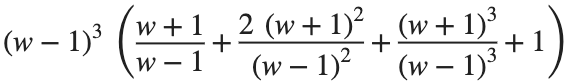

Finally, let us simplify the resulting expression

```matlab
q_Aw = simplify(q_Aw)
```

[output not shown]

q_Aw =

What if the characteristic polynomial to be transformed $p_{A}(z)$ contains some parametric coefficients?

For example, consider the polynomial

$p_A(z) = z^2 +a z +b \quad a , b \in \mathbb{R}$

```matlab
clear
clc
syms z w % the symbolic variables used to describe the polynomial and the bilinear transform
syms a b % the parametric coefficients
```

Now define the polynomial

```matlab
p_Az = z^2+a*z +b
```

[output not shown]

p_Az =

and the bilinear transform

```matlab
bTexpr = (w+1)/(w-1) % the bilinear transform
```

[output not shown]

bTexpr =

Apply the bilinear transform

```matlab
q_w = ((w-1)^2)*subs(p_Az,z,bTexpr)
```

q_w =

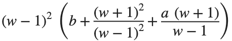

and simplify the result:

```matlab
expand(q_w)
```

ans =

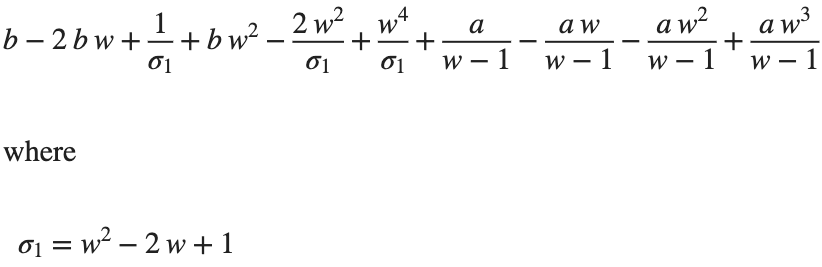

```matlab
simplify(expand(q_w))
```

ans =

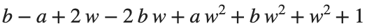

```matlab
q_w = collect(simplify(expand(q_w)),w)
```

q_w =

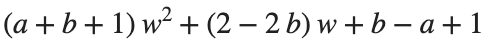